# University of Arkansas Admissions

Daniel Justice

8/8/2020

## Simple Linear Regression Analysis of Male and Female Applicants to the University of Arkansas

Linear regression is a mathematical method to determine a line of “best fit” between two pairs of data collections (Rolf, 2013, p. 198). It is often found in conjunction with a scatter plot. One of the first steps when performing regression analysis is to determine if linear regression is appropriate for your data. In other words, you must ask the question, “Is there a linear relationship between these data collections?” Before we address this question, we need some data!

My data set is sourced from yearly data available at https://oir.uark.edu/cds/index.php. There are many different data to choose from, but let’s narrow our the search to first-time, first-year students. The data is split between male and female gender, and subdivided into categories of applied, admitted, part-time enrolled, and full-time enrolled. We are looking at the collection from 1998 to 2019.

### Data fit

First, I wish to compare the number of female applicants to the number of male applicants each year. The best visual tool for this is a scatter plot as seen in the following image.

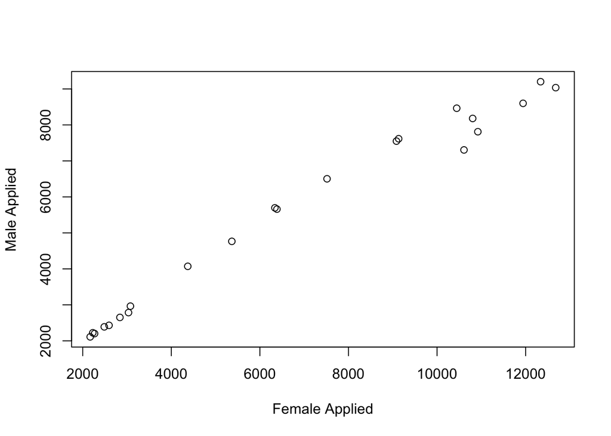

There is clearly a linear relationship between these data points, and our intuition correctly tells us that we could make reasonable predictions with a line of best-fit. However, we cannot blindly assume that this is the case for all of our data. Let’s look at the relationship between female applicants and female full-time enrollments.

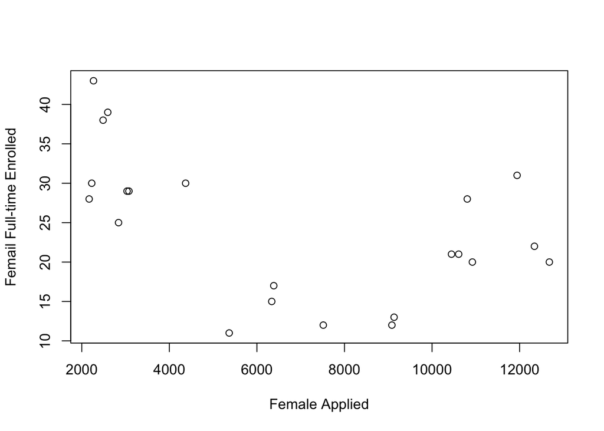

### r-values

You would be hard-pressed to determine a linear relationship with this data! Although we didn’t study it in the course materials, it is important to evaluate the correlation coefficient (or “r-value”) between pairs of data. What we see in the scatter plot can be determined numerically “by computing z score values for each value for both x and y, where z is obtained by subtracting the mean from each value and dividing by the distribution’s standard deviation.” (Maher, n.d.) Values close to $|1|$ mean that there is a strong linear relationship. The first plot of male to female applicants has an r-value of 0.989, and the latter plot has an r-value of -0.497. This means that the first data set is much more appropriate for linear regression analysis.

### Linear regression

As mentioned earlier, linear regression allows us to find a line of “best-fit” for the data in question. The textbook doesn’t go into great detail on the subject, nor do most introductory articles you find on the Internet. The formula uses the square of the distance between a value and the best-fit line to eliminate variance caused by negative values. We need to minimize the value of a squared, or quadratic function (Weisstein, 2020).

$$R^2 (a,b) \equiv \sum_{i=1}^{n} [y_i - f(x_i, a+bx_i)]^2$$
There are two unknowns that we are interested in. The y-intercept $a$ and the slope $b$. Since this is a quadratic, we know that a minimum or maximum will be where the first derivative is equal to zero. This formula may appear a little daunting at first, but to invoke some old Professor Ghrist videos, we simply need to find the derivative of “blah” squared. Keep in mind that since we are dealing with two unknowns, we have to find the derivative with respect to $a$ and *separately* with respect to $b$.

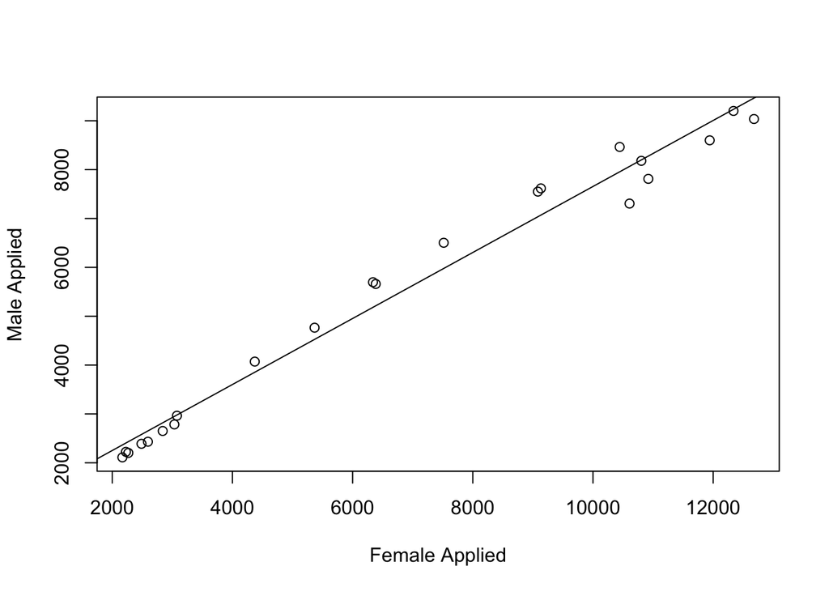

## References

Kirchner, J. (n.d.). Data Analysis Toolkit #10: Simple linear regression. Berkeley Seismology Lab. Retrieved August 24, 2020, from http://seismo.berkeley.edu/~kirchner/eps_120/Toolkits/Toolkit_10.pdf

Maher, H. D. (n.d.). linear regression and correlation coefficients. Cartography and Geographic Information Systems Laboratory. Retrieved August 24, 2020, from http://maps.unomaha.edu/Maher/GEOL2300/week3/week3.html

Rolf, H. L. (2013). Finite Mathematics (8th ed.). Cengage Learning.

Weisstein, E. W. (2020, August 24). Least Squares Fitting – from Wolfram MathWorld. Wolfram MathWorld. https://mathworld.wolfram.com/LeastSquaresFitting.html